# Unsupervised Learning Project

by

Prashant Patil

AIML Online October 2023-A Batch

17 Mar 2024

- Import libraries

### Part A

**Tasks Planned**

1. Data Understanding & Exploration
2. Check null values
3. Check duplicates
4. Pairplot & Bi-variate analysis
5. Check unexpected values : Blanks and special characters
6. Drop unwanted column 'car names' and standardize data
7. Apply K means for 2-10 range and plot performance for Elbow method
8. Determine best K and apply K means with it for forming clusters
9. Visualize data to measure specificity and clear isolation of clusters
10. Pass new data point and check if correct cluster is returned by model

### Part B

```python
import pandas as pd
import numpy as np
import re
# import plotly
# import plotly.express as px

import matplotlib.pylab as plt
%matplotlib inline
import seaborn as sns
from sklearn.model_selection  import train_test_split
from sklearn.cluster import KMeans
from scipy.spatial.distance import cdist
from scipy.stats import zscore
from sklearn.preprocessing import StandardScaler
from sklearn.metrics import silhouette_samples, silhouette_score
import warnings
warnings.filterwarnings("ignore")
from sklearn.svm import SVC
from sklearn.metrics import accuracy_score, precision_score, recall_score, f1_score, classification_report
from sklearn.model_selection import GridSearchCV
from pandas.plotting import parallel_coordinates
from sklearn.decomposition import PCA
```

# Part A

### Q.1. Data Understanding & Exploration:

### Q.1.A. Read ‘Car name.csv’ as a DataFrame and assign it to a variable

```python
dfCar = pd.read_csv("Car name.csv")
dfCar.head()
```

|  | car_name |
| --- | --- |
| 0 | chevrolet chevelle malibu |
| 1 | buick skylark 320 |
| 2 | plymouth satellite |
| 3 | amc rebel sst |
| 4 | ford torino |

### Q.1.B. Read ‘Car-Attributes.json as a DataFrame and assign it to a variable.

```python
dfAttr = pd.read_json("Car-Attributes.json")
dfAttr.head()
```

|  | mpg | cyl | disp | hp | wt | acc | yr | origin |
| --- | --- | --- | --- | --- | --- | --- | --- | --- |
| 0 | 18.0 | 8 | 307.0 | 130 | 3504 | 12.0 | 70 | 1 |
| 1 | 15.0 | 8 | 350.0 | 165 | 3693 | 11.5 | 70 | 1 |
| 2 | 18.0 | 8 | 318.0 | 150 | 3436 | 11.0 | 70 | 1 |
| 3 | 16.0 | 8 | 304.0 | 150 | 3433 | 12.0 | 70 | 1 |
| 4 | 17.0 | 8 | 302.0 | 140 | 3449 | 10.5 | 70 | 1 |

### Q.1.C. Merge both the DataFrames together to form a single DataFrame

```python
dfMerged = pd.concat([dfCar,dfAttr], axis=1)
dfMerged.head()
dfMerged.shape
```

```
(398, 9)
```

### Q.1.D. Print 5 point summary of the numerical features and share insights.

```python
#We can observe 5 point summary using quantile method
dfnumeric = dfMerged.drop('car_name', axis=1)
dfnumeric = dfnumeric.apply(pd.to_numeric, errors='coerce')
# Calculate the five-number summary of the numerical features
summary = dfnumeric.quantile([0, 0.25, 0.5, 0.75, 1]).T
print("5 point summary of the numerical features:")
print(summary)
```

```
5 point summary of the numerical features:
          0.00      0.25    0.50      0.75    1.00
mpg        9.0    17.500    23.0    29.000    46.6
cyl        3.0     4.000     4.0     8.000     8.0
disp      68.0   104.250   148.5   262.000   455.0
hp        46.0    75.000    93.5   126.000   230.0
wt      1613.0  2223.750  2803.5  3608.000  5140.0
acc        8.0    13.825    15.5    17.175    24.8
yr        70.0    73.000    76.0    79.000    82.0
origin     1.0     1.000     1.0     2.000     3.0
```

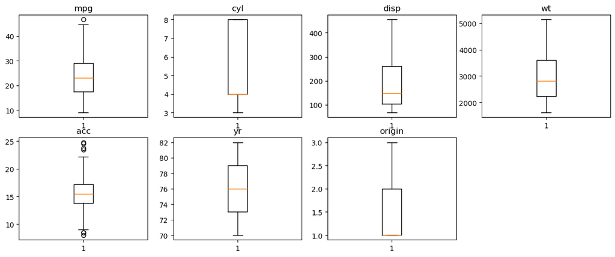

```python
#Lets plot boxplots to have more insights into 5 point summary
numeric_columns = ['mpg', 'cyl', 'disp', 'wt', 'acc', 'yr', 'origin']
plt.figure(figsize=(15, 12))
for i, variable in enumerate(numeric_columns):
    plt.subplot(4, 4, i + 1)
    plt.boxplot(dfMerged[variable])
    #plt.tight_layout();
    plt.title(variable)
plt.show();
```

## Q.2. Data Preparation & Analysis:

### Q.2.A. Check and print feature-wise percentage of missing values present in the data and impute with the best suitable approach

```python
print("percentage of missing data of dataframe \n",(dfMerged.isnull().sum()/len(dfMerged))*100)
```

```
percentage of missing data of dataframe
 car_name    0.0
mpg         0.0
cyl         0.0
disp        0.0
hp          0.0
wt          0.0
acc         0.0
yr          0.0
origin      0.0
dtype: float64
```

No missing values found in data

### Q.2.B. Check for duplicate values in the data and impute with the best suitable approach.

```python
# Check for duplicate rows
duplicate_rows = dfMerged[dfMerged.duplicated()]

# Count the number of duplicate rows
num_duplicate_rows = duplicate_rows.shape[0]

if num_duplicate_rows == 0:
    print("No duplicate rows found.")
else:
    print(f"{num_duplicate_rows} duplicate rows found.")
    print(duplicate_rows)
```

```
No duplicate rows found.
```

### Q.2.C. Plot a pairplot for all features

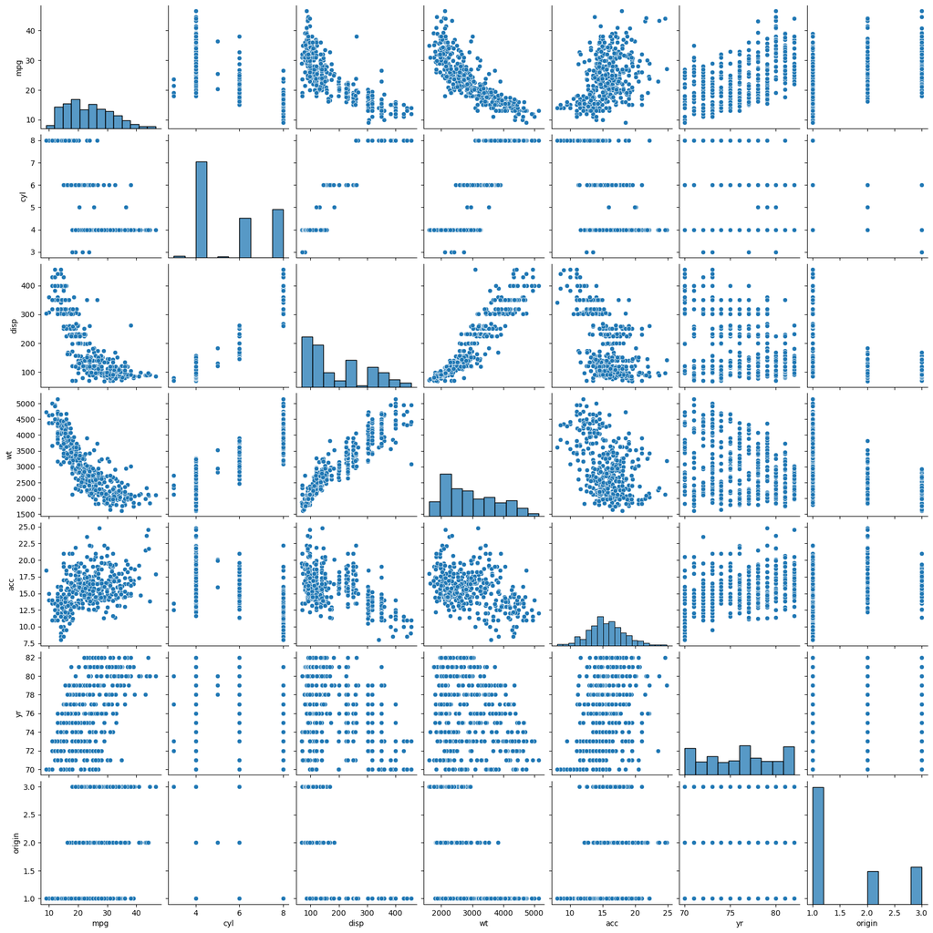

```python
pairplot = sns.pairplot(dfMerged, palette='Set1')
plt.show()
```

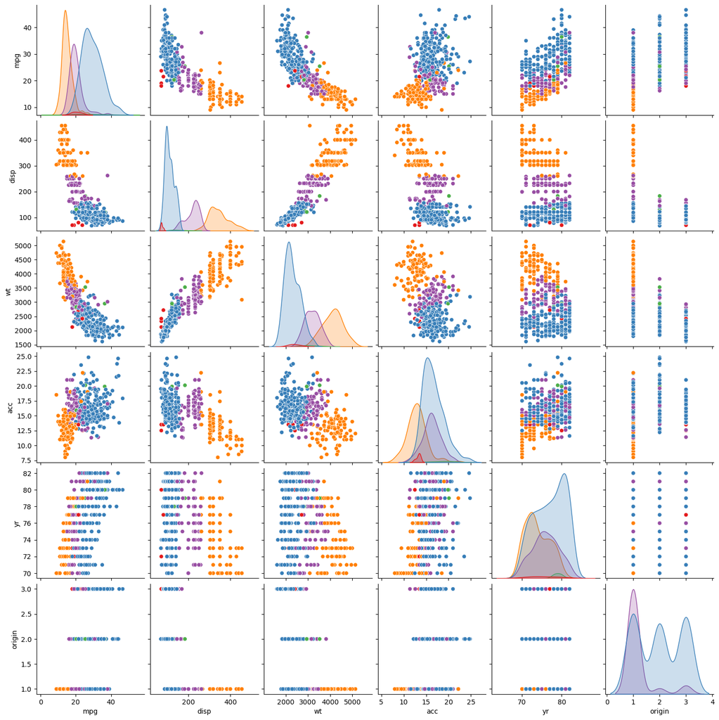

```python
#Lets plot a pairplot with hue parameter 'cyl'
pairplot = sns.pairplot(dfMerged, hue='cyl', palette='Set1')
pairplot._legend.remove()
plt.show()
```

### Q.2.D. Visualize a scatterplot for ‘wt’ and ‘disp’. Datapoints should be distinguishable by ‘cyl’

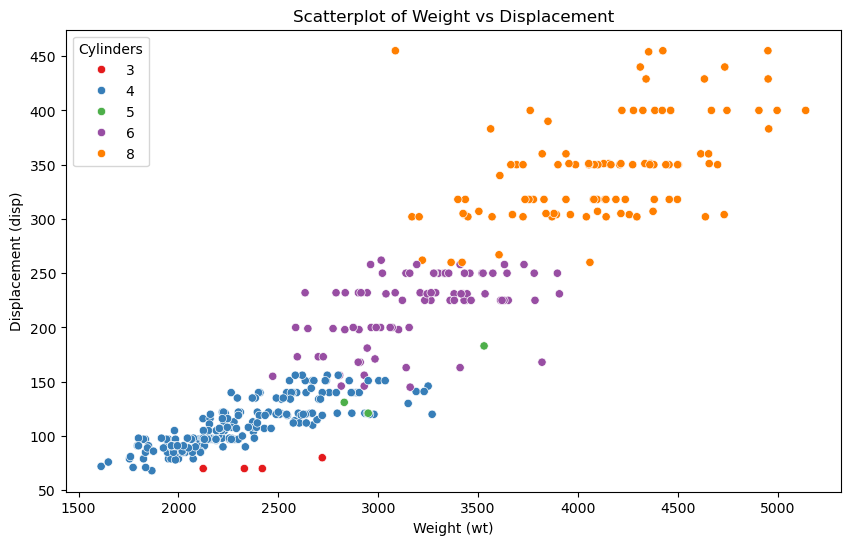

```python
plt.figure(figsize=(10, 6))
sns.scatterplot(data=dfMerged, x='wt', y='disp', hue='cyl', palette='Set1')

# Add labels and title
plt.xlabel('Weight (wt)')
plt.ylabel('Displacement (disp)')
plt.title('Scatterplot of Weight vs Displacement')

# Show legend
plt.legend(title='Cylinders')

# Show plot
plt.show()
```

### Q.2.E. Share insights for Q2.d.

**Positive correlation between weight (wt), displacement (disp), and cylinder count (cyl):**

- Relationship between weight (wt) and displacement (disp):

- Impact of cylinder count (cyl) on weight (wt) and displacement - (disp):

### Q.3.F. Visualize a scatterplot for ‘wt’ and ’mpg’. Datapoints should be distinguishable by ‘cyl’.

[figure not shown]

```python
plt.figure(figsize=(10, 6))
sns.scatterplot(data=dfMerged, x='wt', y='mpg', hue='cyl', palette='Set1')

# Add labels and title
plt.xlabel('Weight (wt)')
plt.ylabel('Miles per gallon (mpg)')
plt.title('Scatterplot of Weight vs Displacement')

# Show legend
plt.legend(title='Cylinders')

# Show plot
plt.show()
```

### Q.2.G.Share insights for Q2.f.

**Relationship between Weight and MPG (Miles Per Gallon):**

- The scatterplot reveals a clear negative correlation between weight and MPG (miles per gallon).
- As weight increases, MPG tends to decrease, indicating that heavier vehicles generally have lower fuel efficiency.
- This negative correlation suggests that weight is a significant factor influencing the fuel economy of vehicles.

**Impact of Cylinder Size on Weight and MPG:**

- Additionally, the scatterplot illustrates a trend where cylinder size, represented by the 'cyl' variable, tends to increase with weight.
- Vehicles with a greater number of cylinders exhibit higher weight, which aligns with the expectation that larger engines contribute to increased vehicle weight.
- However, despite the increase in weight with cylinder size, MPG tends to decrease.
- This observation underscores the trade-off between engine power (often associated with larger cylinders) and fuel efficiency, where vehicles with larger engines may sacrifice MPG for performance.

The insights fetched from the scatterplot emphasize the interplay between weight, cylinder size, and MPG in determining the fuel efficiency and performance characteristics of vehicles. While heavier vehicles and larger engine sizes may offer enhanced power and performance, they typically come at the expense of reduced fuel efficiency, as indicated by the negative correlation between weight and MPG. This trade-off underscores the importance of optimizing vehicle design and engine specifications to strike a balance between performance and fuel economy, addressing the diverse needs and preferences of consumers.

### Q.2.H.Check for unexpected values in all the features and datapoints with such values.

As we have already ruled out possibility of null values in data, lte us check if variables that are supposed to have numeric values have any special characters or blanks.

```python
# Function to find special characters in a string
def find_special_characters(text):
    special_characters = re.compile(r'[^a-zA-Z0-9\s]')
    return special_characters.findall(text)

# Function to check if a string consists of only numeric characters
def is_numeric1(text):
    print(text.replace('.', '', 1).isdigit())
    return text.replace('.', '', 1).isdigit()
#Lets check if each column has any special characters and blank values
for column in dfMerged.columns:
    if column != 'car_name':
        for index, value in dfMerged[column].items():
            if isinstance(value, str) and value.strip():  # Check if the value is a non-empty string
                special_chars = find_special_characters(value)
                if special_chars:
                    print(f"Special characters found in column '{column}', row '{index}': {special_chars}")
            elif isinstance(value, float) and np.isnan(value):  # Check if the value is NaN
                print(f"Blank value found in column '{column}', row '{index}'")
```

```
Special characters found in column 'hp', row '32': ['?']
Special characters found in column 'hp', row '126': ['?']
Special characters found in column 'hp', row '330': ['?']
Special characters found in column 'hp', row '336': ['?']
Special characters found in column 'hp', row '354': ['?']
Special characters found in column 'hp', row '374': ['?']
```

```python
#Now that we have checked abnormilities, lets check if all are numeric columns.
numeric_column = dfMerged[['mpg', 'cyl', 'disp', 'hp', 'wt', 'acc', 'yr', 'origin']].apply(pd.to_numeric, errors='coerce')
numeric_column.isna().sum()
```

```
mpg       0
cyl       0
disp      0
hp        6
wt        0
acc       0
yr        0
origin    0
dtype: int64
```

```python
#Lets replace '?' with Nan in hp column
dfMerged['hp'] = dfMerged['hp'].replace('?', np.nan)
#We should see Nan values in hp column
dfMerged.isna().sum()
#Lets replace Nan with median values
dfMerged['hp'] = dfMerged['hp'].fillna(dfMerged['hp'].median())
```

## Q.2. Clustering:

### Q.2.A. Apply K-Means clustering for 2 to 10 clusters.

```python
#lets drop column car name before applying clustering
df = dfMerged.drop('car_name',axis = 1)

#lets scale the data as features are having different unit of measures
# scaled_df = df.apply(zscore)
scaler = StandardScaler()
scaled_data  = scaler.fit_transform(df)
scaled_df = pd.DataFrame(scaled_data, columns=df.columns)

#Lets apply kmeans clustering for k=2-10
clusters=range(2,11)
meanDistortions=[]
wss = []
for k in clusters:
    model=KMeans(n_clusters=k)
    model.fit(scaled_df)
    # prediction=model.predict(scaled_df)
    meanDistortions.append(sum(np.min(cdist(scaled_df, model.cluster_centers_, 'euclidean'), axis=1)) / scaled_df.shape[0])
    #Lets store in cluster sum of squares
    wss.append(model.inertia_)
```

### Q.3.B. Plot a visual and find elbow point.

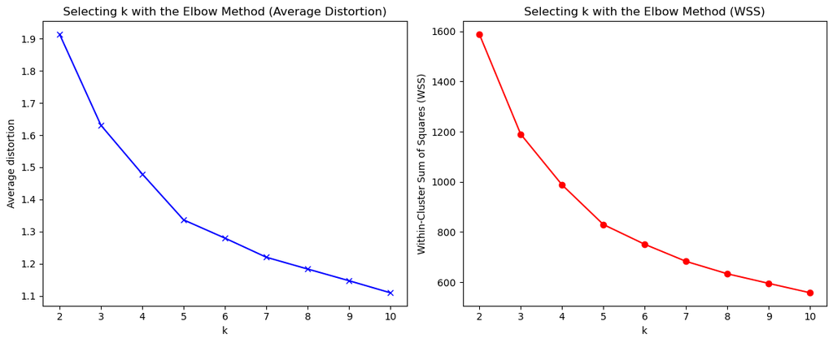

```python
#Lets plot average distortion and within cluster sum of squares against different k values in separate plots
plt.figure(figsize=(12, 5))

plt.subplot(1, 2, 1)  # Subplot 1: Average Distortion
plt.plot(clusters, meanDistortions, 'bx-')
plt.xlabel('k')
plt.ylabel('Average distortion')
plt.title('Selecting k with the Elbow Method (Average Distortion)')

# Plotting WSS
plt.subplot(1, 2, 2)  # Subplot 2: WSS
plt.plot(range(2, 11), wss, 'ro-')
plt.xlabel('k')
plt.ylabel('Within-Cluster Sum of Squares (WSS)')
plt.title('Selecting k with the Elbow Method (WSS)')

plt.tight_layout()
plt.show()
```

### Q.3.C. On the above visual, highlight which are the possible Elbow points.

Form above plot of avg distortion against k values, it can be infered that there are two points which can be considered as elbow points.

1. k = 5 There is considerable deviation at this point
2. k = 7 This also signifies deviation so this also can be considered as elbow point

Both of these points can be considered as elbow points and can be used to find optimum k to find best clustering.

### Q.3.D. Train a K-means clustering model once again on the optimal number of clusters.

```python
final_model=KMeans(n_clusters = 5, random_state=0)
final_model.fit(scaled_df)
labels = final_model.labels_

#Find silhouette_score for kmeans model with k=4
silhouette_score(scaled_df,labels)
```

```
0.33296973781495653
```

```python
#Lets verify if we get better silhouette score with k=7
final_model_k7=KMeans(7, random_state=0)
final_model_k7.fit(scaled_df)
labels_k7 = final_model_k7.labels_
#Find silhouette_score for kmeans model with k=8
silhouette_score(scaled_df,labels_k7)
```

```
0.29613743723302555
```

We observed best silhouette_score when original data used for k means with k value as 5.

**Best/optimal k : 5**

### Q.3.E. Add a new feature in the DataFrame which will have labels based upon cluster value.

```python
#Lets store clusters (label) in new feature in both scaled and original dataframe
df["label"] = labels
scaled_df["label"] = labels
df.head(2)
```

|  | mpg | cyl | disp | hp | wt | acc | yr | origin | label |
| --- | --- | --- | --- | --- | --- | --- | --- | --- | --- |
| 0 | 18.0 | 8 | 307.0 | 130.0 | 3504 | 12.0 | 70 | 1 | 1 |
| 1 | 15.0 | 8 | 350.0 | 165.0 | 3693 | 11.5 | 70 | 1 | 1 |

```python
#Lets check how specific clusters have been formed by checking mean values of each variable group by clusters
print("Groups by labels : \n")
dfgroup = df.groupby(['label'])
dfgroup.mean()
```

```
Groups by labels :
```

| label | mpg | cyl | disp | hp | wt | acc | yr | origin |
| --- | --- | --- | --- | --- | --- | --- | --- | --- |
| 0 | 34.137500 | 4.083333 | 99.527778 | 72.875000 | 2155.819444 | 16.734722 | 79.416667 | 2.763889 |
| 1 | 14.429787 | 8.000000 | 350.042553 | 162.393617 | 4157.978723 | 12.576596 | 73.468085 | 1.000000 |
| 2 | 24.619048 | 4.047619 | 108.601190 | 85.672619 | 2347.619048 | 16.107143 | 73.309524 | 2.107143 |
| 3 | 28.791045 | 4.194030 | 132.567164 | 82.865672 | 2563.805970 | 16.549254 | 79.671642 | 1.074627 |
| 4 | 19.104938 | 6.222222 | 233.444444 | 101.882716 | 3298.580247 | 16.632099 | 75.703704 | 1.037037 |

### Q.3.F. Plot a visual and color the datapoints based upon clusters

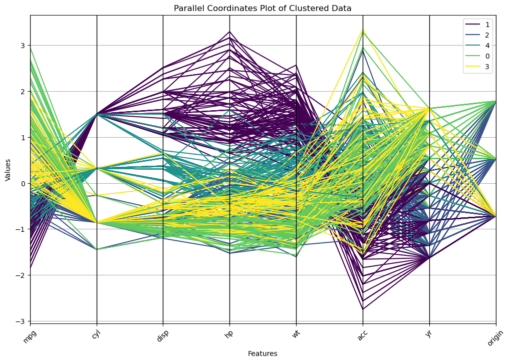

```python
# Lets plot Parallel Coordinates Plot to show clusters within data
plt.figure(figsize=(12, 8))
parallel_coordinates(scaled_df, 'label', colormap='viridis')
plt.title('Parallel Coordinates Plot of Clustered Data')
plt.xlabel('Features')
plt.ylabel('Values')
plt.xticks(rotation=45)
plt.legend(loc='upper right')
plt.show()
```

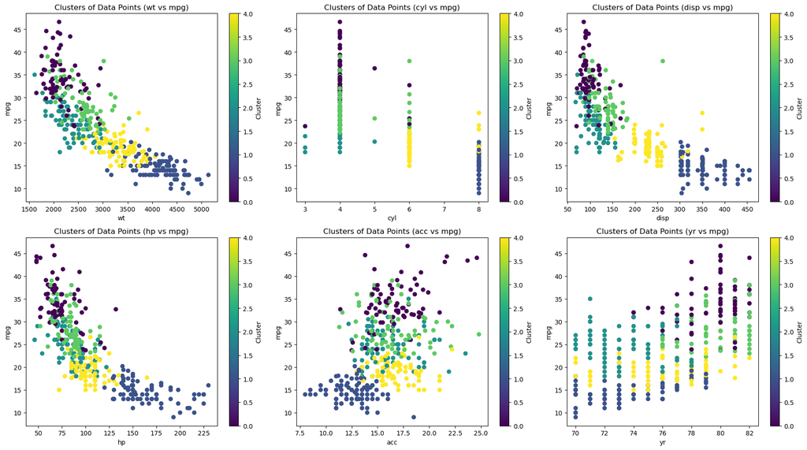

```python
#Lets plot scatter plots for each variable against mpg to find clusters across multiple combinations
plt.figure(figsize=(18, 10))

# Scatter plot for wt vs mpg
plt.subplot(2, 3, 1)
plt.scatter(df['wt'], df['mpg'], c=df['label'], cmap='viridis')
plt.xlabel('wt')
plt.ylabel('mpg')
plt.title('Clusters of Data Points (wt vs mpg)')
plt.colorbar(label='Cluster')

# Scatter plot for cyl vs mpg
plt.subplot(2, 3, 2)
plt.scatter(df['cyl'], df['mpg'], c=df['label'], cmap='viridis')
plt.xlabel('cyl')
plt.ylabel('mpg')
plt.title('Clusters of Data Points (cyl vs mpg)')
plt.colorbar(label='Cluster')

# Scatter plot for disp vs mpg
plt.subplot(2, 3, 3)
plt.scatter(df['disp'], df['mpg'], c=df['label'], cmap='viridis')
plt.xlabel('disp')
plt.ylabel('mpg')
plt.title('Clusters of Data Points (disp vs mpg)')
plt.colorbar(label='Cluster')

# Scatter plot for hp vs mpg
plt.subplot(2, 3, 4)
plt.scatter(df['hp'], df['mpg'], c=df['label'], cmap='viridis')
plt.xlabel('hp')
plt.ylabel('mpg')
plt.title('Clusters of Data Points (hp vs mpg)')
plt.colorbar(label='Cluster')

# Scatter plot for acc vs mpg
plt.subplot(2, 3, 5)
plt.scatter(df['acc'], df['mpg'], c=df['label'], cmap='viridis')
plt.xlabel('acc')
plt.ylabel('mpg')
plt.title('Clusters of Data Points (acc vs mpg)')
plt.colorbar(label='Cluster')

# Scatter plot for yr vs mpg
plt.subplot(2, 3, 6)
plt.scatter(df['yr'], df['mpg'], c=df['label'], cmap='viridis')
plt.xlabel('yr')
plt.ylabel('mpg')
plt.title('Clusters of Data Points (yr vs mpg)')
plt.colorbar(label='Cluster')

plt.tight_layout()
plt.show()
```

```
array([[<Axes: title={'center': 'acc'}, xlabel='[label]'>,
        <Axes: title={'center': 'cyl'}, xlabel='[label]'>,
        <Axes: title={'center': 'disp'}, xlabel='[label]'>,
        <Axes: title={'center': 'hp'}, xlabel='[label]'>],
       [<Axes: title={'center': 'mpg'}, xlabel='[label]'>,
        <Axes: title={'center': 'origin'}, xlabel='[label]'>,
        <Axes: title={'center': 'wt'}, xlabel='[label]'>,
        <Axes: title={'center': 'yr'}, xlabel='[label]'>]], dtype=object)
```

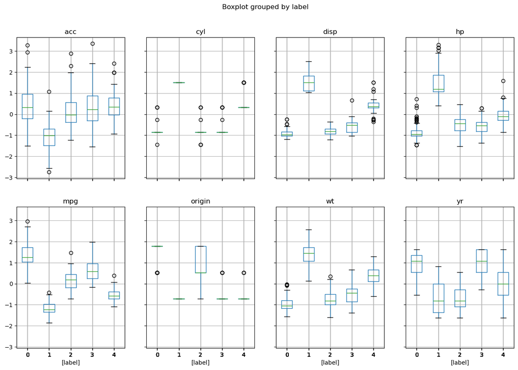

```python
#Lets plot boxplots to verify isolation of clusters
scaled_df.boxplot(by='label', layout = (2,4),figsize=(15,10))
```

### Q.3.G. Pass a new DataPoint and predict which cluster it belongs to

```python
#Lets pass few new datapoints and see which cluster those belongs to
new_data_points = [
    {"mpg": 24, "cyl": 4, "disp": 151, "hp": 94, "wt": 2100, "acc": 15, "yr": 77, "origin": 1.5},
    {"mpg": 30, "cyl": 4, "disp": 125, "hp": 80, "wt": 2500, "acc": 16.0, "yr": 79, "origin": 2},
    {"mpg": 19, "cyl": 5, "disp": 221, "hp": 100, "wt": 3228, "acc": 16, "yr": 76, "origin": 1},
]
new_data_df = pd.DataFrame(new_data_points)

#Original dataset is in scaled format so lets scale the data point to be predicted
scaler = StandardScaler()
new_data_df = scaler.fit_transform(new_data_df)

# Predict the cluster labels for the new data points using the trained model
predicted_labels = final_model.predict(new_data_df)

# Print the input data points along with the predicted cluster labels
for i, (data_point, label) in enumerate(zip(new_data_points, predicted_labels)):
    print(f"Data point {i + 1}: {data_point}, Predicted cluster label: {label}")
```

```
Data point 1: {'mpg': 24, 'cyl': 4, 'disp': 151, 'hp': 94, 'wt': 2100, 'acc': 15, 'yr': 77, 'origin': 1.5}, Predicted cluster label: 2
Data point 2: {'mpg': 30, 'cyl': 4, 'disp': 125, 'hp': 80, 'wt': 2500, 'acc': 16.0, 'yr': 79, 'origin': 2}, Predicted cluster label: 0
Data point 3: {'mpg': 19, 'cyl': 5, 'disp': 221, 'hp': 100, 'wt': 3228, 'acc': 16, 'yr': 76, 'origin': 1}, Predicted cluster label: 1
```

# Part B : DOMAIN: Automobile

## Q.1. Data Understanding & Cleaning

### Q.1.A. Read ‘vehicle.csv’ and save as DataFrame

```python
#Read data
df_vehicle = pd.read_csv("vehicle.csv")
df_vehicle.head()
```

|  | compactness | circularity | distance_circularity | radius_ratio | pr.axis_aspect_ratio | max.length_aspect_ratio | scatter_ratio | elongatedness | pr.axis_rectangularity | max.length_rectangularity | scaled_variance | scaled_variance.1 | scaled_radius_of_gyration | scaled_radius_of_gyration.1 | skewness_about | skewness_about.1 | skewness_about.2 | hollows_ratio | class |
| --- | --- | --- | --- | --- | --- | --- | --- | --- | --- | --- | --- | --- | --- | --- | --- | --- | --- | --- | --- |
| 0 | 95 | 48.0 | 83.0 | 178.0 | 72.0 | 10 | 162.0 | 42.0 | 20.0 | 159 | 176.0 | 379.0 | 184.0 | 70.0 | 6.0 | 16.0 | 187.0 | 197 | van |
| 1 | 91 | 41.0 | 84.0 | 141.0 | 57.0 | 9 | 149.0 | 45.0 | 19.0 | 143 | 170.0 | 330.0 | 158.0 | 72.0 | 9.0 | 14.0 | 189.0 | 199 | van |
| 2 | 104 | 50.0 | 106.0 | 209.0 | 66.0 | 10 | 207.0 | 32.0 | 23.0 | 158 | 223.0 | 635.0 | 220.0 | 73.0 | 14.0 | 9.0 | 188.0 | 196 | car |
| 3 | 93 | 41.0 | 82.0 | 159.0 | 63.0 | 9 | 144.0 | 46.0 | 19.0 | 143 | 160.0 | 309.0 | 127.0 | 63.0 | 6.0 | 10.0 | 199.0 | 207 | van |
| 4 | 85 | 44.0 | 70.0 | 205.0 | 103.0 | 52 | 149.0 | 45.0 | 19.0 | 144 | 241.0 | 325.0 | 188.0 | 127.0 | 9.0 | 11.0 | 180.0 | 183 | bus |

### Q.1.B. Check percentage of missing values and impute with correct approach.

```python
# Check percentage of missing values
print("percentage of missing data of dataframe \n",((df_vehicle.isnull().sum()/len(df_vehicle))*100).round(2))
```

```
percentage of missing data of dataframe
 compactness                    0.00
circularity                    0.59
distance_circularity           0.47
radius_ratio                   0.71
pr.axis_aspect_ratio           0.24
max.length_aspect_ratio        0.00
scatter_ratio                  0.12
elongatedness                  0.12
pr.axis_rectangularity         0.35
max.length_rectangularity      0.00
scaled_variance                0.35
scaled_variance.1              0.24
scaled_radius_of_gyration      0.24
scaled_radius_of_gyration.1    0.47
skewness_about                 0.71
skewness_about.1               0.12
skewness_about.2               0.12
hollows_ratio                  0.00
class                          0.00
dtype: float64
```

```python
#impute missing values with appropriate approach only for those columns of df_vehicle having missing values.
#We observe that missing values are in many numeric (integer) variables. Hence we will impute with rounded value of mean
for column in df_vehicle.columns:
  if df_vehicle[column].isna().any():
    df_vehicle[column] = df_vehicle[column].fillna(round(df_vehicle[column].mean()))

print("percentage of missing data of dataframe \n",(df_vehicle.isnull().sum()/len(df_vehicle))*100)
```

```
percentage of missing data of dataframe
 compactness                    0.0
circularity                    0.0
distance_circularity           0.0
radius_ratio                   0.0
pr.axis_aspect_ratio           0.0
max.length_aspect_ratio        0.0
scatter_ratio                  0.0
elongatedness                  0.0
pr.axis_rectangularity         0.0
max.length_rectangularity      0.0
scaled_variance                0.0
scaled_variance.1              0.0
scaled_radius_of_gyration      0.0
scaled_radius_of_gyration.1    0.0
skewness_about                 0.0
skewness_about.1               0.0
skewness_about.2               0.0
hollows_ratio                  0.0
class                          0.0
dtype: float64
```

### Q.1.C. Visualize a Pie-chart and print percentage of values for variable ‘class’.

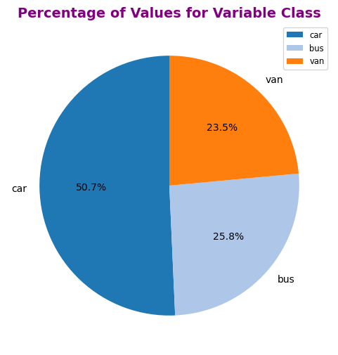

```python
# class_counts = df_vehicle['class'].value_counts(normalize=True)
# class_counts_df = class_counts.reset_index()
# class_counts_df.columns = ['class', 'percentage']
# fig = px.pie(class_counts_df, values='percentage', names='class',title='Percentage of Values for Variable Class')
# fig.show()
#Lets avoid plotly as it increases file size
class_counts = df_vehicle['class'].value_counts(normalize=True) * 100
# Plot the pie chart
plt.figure(figsize=(6, 6))
class_counts.plot(kind='pie', autopct='%1.1f%%', startangle=90, colors=plt.cm.tab20.colors)
plt.title('Percentage of Values for Variable Class', fontsize=14, weight='bold', color='purple')
plt.ylabel('')
plt.legend(loc="best", fontsize='small', labels=class_counts.index)
plt.show()
```

### Q.1.D. Check for duplicate rows in the data and impute with correct approach.

```python
# Check for duplicate rows in the data
duplicate_rows = df_vehicle[df_vehicle.duplicated()]
# Count the number of duplicate rows
num_duplicate_rows = duplicate_rows.shape[0]
if num_duplicate_rows == 0:
    print("No duplicate rows found.")
else:
    print(f"{num_duplicate_rows} duplicate rows found.")
    print(duplicate_rows)
```

```
No duplicate rows found.
```

#### Data understanding

```python
#We will try to check correlation across variables
# This can be ran on demand and commenting to avoid delayed execution
# sns.pairplot(df_vehicle, palette='Set1')
# plt.show()
correlation_matrix = df_vehicle.drop('class', axis=1).corr()
# Print the correlation matrix
correlation_matrix
```

|  | compactness | circularity | distance_circularity | radius_ratio | pr.axis_aspect_ratio | max.length_aspect_ratio | scatter_ratio | elongatedness | pr.axis_rectangularity | max.length_rectangularity | scaled_variance | scaled_variance.1 | scaled_radius_of_gyration | scaled_radius_of_gyration.1 | skewness_about | skewness_about.1 | skewness_about.2 | hollows_ratio |
| --- | --- | --- | --- | --- | --- | --- | --- | --- | --- | --- | --- | --- | --- | --- | --- | --- | --- | --- |
| compactness | 1.000000 | 0.685523 | 0.789912 | 0.689845 | 0.091784 | 0.148249 | 0.812231 | -0.788647 | 0.813505 | 0.676143 | 0.762792 | 0.815890 | 0.585135 | -0.249847 | 0.236078 | 0.157478 | 0.298525 | 0.365552 |
| circularity | 0.685523 | 1.000000 | 0.793115 | 0.620932 | 0.153345 | 0.251151 | 0.848386 | -0.822042 | 0.845463 | 0.962059 | 0.796966 | 0.838719 | 0.927098 | 0.053039 | 0.144567 | -0.011929 | -0.105858 | 0.045104 |
| distance_circularity | 0.789912 | 0.793115 | 1.000000 | 0.767111 | 0.158457 | 0.264558 | 0.904394 | -0.911434 | 0.893044 | 0.774664 | 0.861992 | 0.887321 | 0.705931 | -0.225686 | 0.114191 | 0.265638 | 0.145575 | 0.332129 |
| radius_ratio | 0.689845 | 0.620932 | 0.767111 | 1.000000 | 0.663657 | 0.450035 | 0.734240 | -0.789811 | 0.707950 | 0.569219 | 0.794065 | 0.720158 | 0.536521 | -0.180621 | 0.048971 | 0.173877 | 0.382120 | 0.471259 |
| pr.axis_aspect_ratio | 0.091784 | 0.153345 | 0.158457 | 0.663657 | 1.000000 | 0.648691 | 0.103795 | -0.183361 | 0.079190 | 0.127231 | 0.273510 | 0.089701 | 0.122196 | 0.152900 | -0.058393 | -0.032222 | 0.239878 | 0.267722 |
| max.length_aspect_ratio | 0.148249 | 0.251151 | 0.264558 | 0.450035 | 0.648691 | 1.000000 | 0.165965 | -0.180044 | 0.161638 | 0.305943 | 0.318952 | 0.143710 | 0.189694 | 0.295653 | 0.015599 | 0.043505 | -0.026188 | 0.143919 |
| scatter_ratio | 0.812231 | 0.848386 | 0.904394 | 0.734240 | 0.103795 | 0.165965 | 1.000000 | -0.970717 | 0.989350 | 0.808349 | 0.948294 | 0.993772 | 0.799249 | -0.027844 | 0.074432 | 0.213211 | 0.005148 | 0.118445 |
| elongatedness | -0.788647 | -0.822042 | -0.911434 | -0.789811 | -0.183361 | -0.180044 | -0.970717 | 1.000000 | -0.949055 | -0.775531 | -0.936716 | -0.955070 | -0.766025 | 0.103371 | -0.052271 | -0.185754 | -0.114716 | -0.216725 |
| pr.axis_rectangularity | 0.813505 | 0.845463 | 0.893044 | 0.707950 | 0.079190 | 0.161638 | 0.989350 | -0.949055 | 1.000000 | 0.811725 | 0.934477 | 0.989452 | 0.797275 | -0.015435 | 0.082830 | 0.214562 | -0.019121 | 0.099112 |
| max.length_rectangularity | 0.676143 | 0.962059 | 0.774664 | 0.569219 | 0.127231 | 0.305943 | 0.808349 | -0.775531 | 0.811725 | 1.000000 | 0.745213 | 0.796010 | 0.866418 | 0.041410 | 0.135852 | 0.001731 | -0.104280 | 0.076770 |
| scaled_variance | 0.762792 | 0.796966 | 0.861992 | 0.794065 | 0.273510 | 0.318952 | 0.948294 | -0.936716 | 0.934477 | 0.745213 | 1.000000 | 0.947018 | 0.778962 | 0.112420 | 0.036267 | 0.195300 | 0.014417 | 0.086628 |
| scaled_variance.1 | 0.815890 | 0.838719 | 0.887321 | 0.720158 | 0.089701 | 0.143710 | 0.993772 | -0.955070 | 0.989452 | 0.796010 | 0.947018 | 1.000000 | 0.796051 | -0.016449 | 0.077232 | 0.201651 | 0.006618 | 0.103757 |
| scaled_radius_of_gyration | 0.585135 | 0.927098 | 0.705931 | 0.536521 | 0.122196 | 0.189694 | 0.799249 | -0.766025 | 0.797275 | 0.866418 | 0.778962 | 0.796051 | 1.000000 | 0.191563 | 0.166408 | -0.055927 | -0.224923 | -0.118195 |
| scaled_radius_of_gyration.1 | -0.249847 | 0.053039 | -0.225686 | -0.180621 | 0.152900 | 0.295653 | -0.027844 | 0.103371 | -0.015435 | 0.041410 | 0.112420 | -0.016449 | 0.191563 | 1.000000 | -0.088333 | -0.126297 | -0.749342 | -0.802387 |
| skewness_about | 0.236078 | 0.144567 | 0.114191 | 0.048971 | -0.058393 | 0.015599 | 0.074432 | -0.052271 | 0.082830 | 0.135852 | 0.036267 | 0.077232 | 0.166408 | -0.088333 | 1.000000 | -0.034740 | 0.115245 | 0.097126 |
| skewness_about.1 | 0.157478 | -0.011929 | 0.265638 | 0.173877 | -0.032222 | 0.043505 | 0.213211 | -0.185754 | 0.214562 | 0.001731 | 0.195300 | 0.201651 | -0.055927 | -0.126297 | -0.034740 | 1.000000 | 0.077432 | 0.205114 |
| skewness_about.2 | 0.298525 | -0.105858 | 0.145575 | 0.382120 | 0.239878 | -0.026188 | 0.005148 | -0.114716 | -0.019121 | -0.104280 | 0.014417 | 0.006618 | -0.224923 | -0.749342 | 0.115245 | 0.077432 | 1.000000 | 0.892861 |
| hollows_ratio | 0.365552 | 0.045104 | 0.332129 | 0.471259 | 0.267722 | 0.143919 | 0.118445 | -0.216725 | 0.099112 | 0.076770 | 0.086628 | 0.103757 | -0.118195 | -0.802387 | 0.097126 | 0.205114 | 0.892861 | 1.000000 |

We can infere that multicolinearity exists in many columns of data

## Q.2. Data Preparation:

**Note**: Steps/data approach to be followed :

1. Split data to X and y
2. Split data to X_Train, y_train (Training) X_test, y_test (Testing data)
3. We will scale data training, testing for initial SVM and original X data for PCA
4. We will perform SVM on training data and will test the model on test data
5. We will perform PCA on whole scaled data (X_scaled)
6. Post PCA dimensionality reduction, we will split this data into train and test to again perform SVM
7. Further, we will use same (PCA) data for SVM with tuned parameters
8. Performance improvement / reduction measuring after PCA/dimensionality reduction.

## Q.2.A. Split data into X and Y.

```python
# Separate features (X) and target (y). Class is our target variable to be predicted.
X = df_vehicle.drop('class', axis=1)
y = df_vehicle['class']
```

```python
#We would like to preserve some data for performance testing of model.
X_train, X_test, y_train, y_test = train_test_split(X,y, test_size = 0.2, random_state = 10) #Only for initial SVM model
```

### Q.2.B. Standardize the Data.

```python
# Standardize the features using StandardScaler
scaler = StandardScaler()
X_scaled = scaler.fit_transform(X)# This will be used for PCA as we will do our PCA
X_scaled = pd.DataFrame(X_scaled, columns=X.columns)

#Below variables for initial (pre-PCA) SVM models
X_train_scaled = scaler.fit_transform(X_train)
X_test_scaled = scaler.fit_transform(X_test)
# Convert the scaled features back to a DataFrame
X_train_scaled = pd.DataFrame(X_train_scaled, columns=X_train.columns)
X_test_scaled = pd.DataFrame(X_test_scaled, columns=X_test.columns)
```

## Q.3. Model Building

## Reusable Common functions

```python
#Lets define a function to store result of each model/combination in dataframe results_df
columns = ['Model','train_acc','test_acc','train_recall','test_recall','train_precision','test_precision','Train_F1','Test_F1']
results_df = pd.DataFrame(columns=columns)
def AddModelResults(df, Model,train_acc,test_acc,train_recall,test_recall,train_precision,test_precision,Train_F1,Test_F1):
    if (df['Model'] == Model).any():
        df.loc[df['Model'] == Model, ['Model','train_acc','test_acc','train_recall','test_recall','train_precision','test_precision','Train_F1','Test_F1']] = [Model, train_acc,test_acc,train_recall,test_recall,train_precision,test_precision,Train_F1,Test_F1]
    else:
        # Append a new row
        new_row = {'Model': Model,'train_acc' : train_acc,'test_acc':test_acc,'train_recall':train_recall,'test_recall':test_recall,'train_precision':train_precision,'test_precision':test_precision, 'Train_F1' : Train_F1,'Test_F1' : Test_F1 }
        df = pd.concat([df, pd.DataFrame([new_row])], ignore_index=True)
    return df
```

```python
# function that actually used to train model and print/save th eoutput of the model
def PrintOutput(dfr,name,Xtrain, Xtest, ytrain, ytest,pred_train, pred_test ):
    # pred_train = np.round(pred_train,2)
    # pred_test = np.round(pred_test,2)

    train_acc = np.round(accuracy_score(y_train,pred_train),2)
    test_acc = np.round(accuracy_score(ytest,pred_test),2)

    train_recall = np.round(recall_score(ytrain,pred_train, average='weighted'),2)
    test_recall = np.round(recall_score(ytest,pred_test, average='weighted'),2)

    train_precision = np.round(precision_score(ytrain,pred_train, average='weighted'),2)
    test_precision = np.round(precision_score(ytest,pred_test, average='weighted'),2)
    train_f1 = np.round(f1_score(ytrain,pred_train, average='weighted'),2)
    test_f1 = np.round(f1_score(ytest, pred_test, average='weighted'),2)
    classification_rep = classification_report(ytest, pred_test)

    print('*'*15, name, '*'*15)
    print("Accuracy on training set : ",train_acc)
    print("Accuracy on test set : ",test_acc)
    print("Recall on training set: ",train_recall)
    print("Recall on test set: ",test_recall)
    print("Precision on training set: ",train_precision)
    print("Precision on test set: ",test_precision)
    print("F1 on train set: ",train_f1)
    print("F1 on test set: ",test_f1)
    print("Classification Report on test data:")
    print(classification_rep)
    return train_acc, train_recall, train_precision, train_f1,test_acc, test_recall, test_precision, test_f1, AddModelResults(dfr, name,train_acc,test_acc,train_recall,test_recall,train_precision,test_precision,train_f1,test_f1)
```

### Q.3.A. Train a base Classification model using SVM.

```python
# Create an SVM classifier
svm_classifier = SVC(gamma = 0.01, C=1)
# svm_classifier = SVC(kernel='linear', gamma = 1, C=1, random_state=40)
# Train the classifier using the scaled features
svm_classifier.fit(X_train_scaled, y_train)
```

```
SVC(C=1, gamma=0.01)
```

### Q.3.B. Print Classification metrics for train data

```python
# Predict the class labels for the training data. We will use defined function for printing metrics
y_pred_train = svm_classifier.predict(X_train_scaled)
y_pred_test = svm_classifier.predict(X_test_scaled)
accuracy, precision, recall, f1,accuracy_test, precision_test, recall_test, f1_test, results_df = PrintOutput(results_df,'Basic SVM model',X_train, X_test,y_train, y_test,y_pred_train, y_pred_test)
```

```
*************** Basic SVM model ***************
Accuracy on training set :  0.95
Accuracy on test set :  0.91
Recall on training set:  0.95
Recall on test set:  0.91
Precision on training set:  0.95
Precision on test set:  0.91
F1 on train set:  0.95
F1 on test set:  0.91
Classification Report on test data:
              precision    recall  f1-score   support

         bus       0.93      0.98      0.96        44
         car       0.95      0.90      0.92        89
         van       0.80      0.86      0.83        37

    accuracy                           0.91       170
   macro avg       0.90      0.91      0.90       170
weighted avg       0.91      0.91      0.91       170
```

### Q.3.C. Apply PCA on the data with 10 components.

```python
# Create a PCA object with 10 components. So we will be reducing features to 10 from original 19
pca = PCA(n_components=10)

# Fit the PCA object on the original scaled data
pca.fit(X_scaled)

# Transform the data using the fitted PCA object
X_pca = pca.transform(X_scaled)

# Convert the transformed data back to a DataFrame
X_pca = pd.DataFrame(X_pca, columns=[f"PC{i+1}" for i in range(10)])
#Lets print transformed data that will be used for further modelling
X_pca.head()
```

|  | PC1 | PC2 | PC3 | PC4 | PC5 | PC6 | PC7 | PC8 | PC9 | PC10 |
| --- | --- | --- | --- | --- | --- | --- | --- | --- | --- | --- |
| 0 | 0.332184 | -0.218516 | 1.001224 | 0.177483 | 0.079406 | -0.754133 | -0.902636 | -0.383076 | -0.869160 | 0.088979 |
| 1 | -1.593949 | -0.420472 | -0.369193 | 0.233851 | 0.694144 | -0.519075 | 0.375664 | 0.247217 | 0.146824 | -0.095447 |
| 2 | 3.767402 | 0.194523 | 0.088453 | 1.203255 | 0.731257 | 0.705522 | -0.032645 | 0.484206 | -0.308689 | -0.468995 |
| 3 | -1.741189 | -2.829293 | 0.109070 | 0.377862 | -0.363197 | -0.488381 | 0.468364 | -0.022746 | -0.028787 | 0.458546 |
| 4 | 0.555825 | 4.756395 | 11.703989 | 0.143922 | 3.258808 | -0.213026 | 2.670867 | -0.446874 | 2.090045 | -0.349682 |

```python
#Lets print eigeen values
print('eigen vectors:')
print(pca.explained_variance_)
```

```
eigen vectors:
[9.40857922 3.01607467 1.90353183 1.18000765 0.91741511 0.53910034
 0.35848757 0.22171754 0.16001827 0.09171639]
```

```python
#Lets print eigeen vectors (10 components)
print('eigen vectors:')
pca.components_
```

```
eigen vectors:
```

```
array([[ 2.75249495e-01,  2.93436413e-01,  3.04547698e-01,
         2.67573675e-01,  8.05079747e-02,  9.72203204e-02,
         3.16867212e-01, -3.14037574e-01,  3.13947136e-01,
         2.82799338e-01,  3.09306994e-01,  3.14144407e-01,
         2.72009995e-01, -2.08336190e-02,  4.14105187e-02,
         5.83399914e-02,  3.01278807e-02,  7.40588607e-02],
       [-1.27055575e-01,  1.26330928e-01, -7.27506890e-02,
        -1.89690531e-01, -1.22182265e-01,  1.06897423e-02,
         4.79997564e-02,  1.28570986e-02,  6.01324431e-02,
         1.16160027e-01,  6.16806485e-02,  5.32303740e-02,
         2.09263671e-01,  4.88463802e-01, -5.50779090e-02,
        -1.24163026e-01, -5.40948728e-01, -5.40277145e-01],
       [-1.19853746e-01, -2.52398821e-02, -5.60148154e-02,
         2.75082061e-01,  6.42038232e-01,  5.91766796e-01,
        -9.76428545e-02,  5.74644586e-02, -1.09590705e-01,
        -1.69747112e-02,  5.64756107e-02, -1.08703426e-01,
        -3.13400688e-02,  2.86289667e-01, -1.15583026e-01,
        -7.55694009e-02,  8.69213364e-03,  3.94843518e-02],
       [ 7.84038098e-02,  1.87516003e-01, -7.07747694e-02,
        -4.23325863e-02,  3.28009096e-02,  3.12065929e-02,
        -9.60582473e-02,  8.27336536e-02, -9.22062974e-02,
         1.87930150e-01, -1.20378699e-01, -9.11960297e-02,
         2.00072843e-01, -6.56568163e-02,  6.05005012e-01,
        -6.65849629e-01,  1.05570734e-01,  4.76262274e-02],
       [ 6.94857915e-02, -8.49752988e-02,  4.08360619e-02,
        -4.60900772e-02, -4.07838041e-02,  2.13661914e-01,
        -1.50654046e-02,  7.67824915e-02,  1.04999510e-03,
        -6.04790437e-02, -4.59460213e-04, -1.93991253e-02,
        -6.16233053e-02,  1.45630913e-01,  7.28928992e-01,
         5.99425516e-01, -1.00691588e-01, -2.98902121e-02],
       [ 1.44730971e-01, -3.00273109e-01, -1.38512211e-01,
         2.48856549e-01,  2.37993646e-01, -4.21399849e-01,
         1.16506256e-01, -1.42409751e-01,  9.58072060e-02,
        -4.61726647e-01,  2.35866438e-01,  1.56401220e-01,
        -1.34662989e-01,  2.41458292e-01,  2.03590849e-01,
        -1.90574513e-01,  1.56501065e-01, -2.41948784e-01],
       [ 4.53804524e-01, -2.47900269e-01,  7.25628250e-02,
        -1.76172829e-01, -3.97027129e-01,  5.01675806e-01,
         6.52223409e-02,  1.37719583e-02,  9.69979719e-02,
        -1.06396480e-01,  1.15403273e-01,  8.36860521e-02,
        -3.74829050e-01,  1.13160450e-01, -8.01312991e-02,
        -2.84977155e-01,  1.90174014e-02,  1.43194415e-02],
       [-5.64073528e-01, -1.79207770e-01,  4.35980526e-01,
         1.03118345e-01, -6.98663430e-02,  1.61429581e-01,
         1.01493927e-01, -2.17103479e-01,  6.24993310e-02,
        -2.50582350e-01,  4.96328528e-02,  4.18247521e-02,
        -1.10328451e-01, -3.39966329e-01,  1.56416104e-01,
        -2.09386681e-01, -3.04383947e-01, -3.16103789e-02],
       [-4.84238447e-01, -1.44755383e-02, -1.67311068e-01,
        -2.29360884e-01, -2.77980545e-01,  1.48366947e-01,
         5.39721960e-02, -1.57226579e-01,  9.14138621e-03,
        -6.38252469e-02,  2.97338197e-01,  8.05261989e-02,
         2.43201477e-01,  3.20598332e-01,  2.23847648e-02,
         9.12570417e-03,  5.16246395e-01,  1.72361257e-01],
       [-2.61181027e-01,  9.71873057e-02, -2.07491131e-01,
        -4.67326328e-02,  1.06776683e-01, -1.17461194e-01,
         1.67780374e-01, -1.52982791e-01,  1.95233822e-01,
         4.69090109e-01, -1.29068587e-01,  1.54267804e-01,
        -6.85606517e-01,  1.27456809e-01,  9.86619355e-02,
        -3.53691326e-02,  2.06829722e-02,  6.33774871e-02]])
```

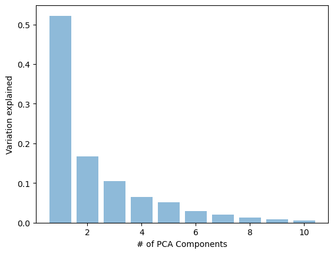

```python
plt.bar(list(range(1,11)),pca.explained_variance_ratio_,alpha=0.5, align='center')
plt.ylabel('Variation explained')
plt.xlabel('# of PCA Components')
plt.show()
```

### Q.3.D. Visualize Cumulative Variance Explained with Number of Components

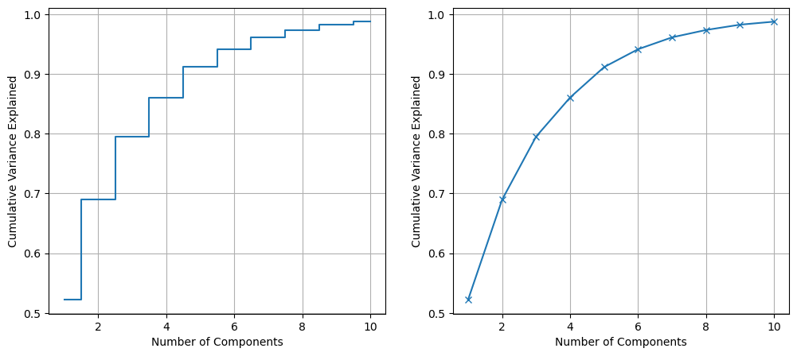

```python
#Visualize Cumulative Variance Explained with Number of Components
cumulative_variance_ratio = np.cumsum(pca.explained_variance_ratio_)

plt.figure(figsize=(12, 5))
plt.subplot(1, 2, 1)
plt.step(range(1, len(cumulative_variance_ratio) + 1), cumulative_variance_ratio, where='mid')
plt.xlabel('Number of Components')
plt.ylabel('Cumulative Variance Explained')
plt.grid(True)

plt.subplot(1, 2, 2)
plt.plot(range(1, len(pca.explained_variance_ratio_) + 1),
         np.cumsum(pca.explained_variance_ratio_),marker='x')
plt.xlabel('Number of Components')
plt.ylabel('Cumulative Variance Explained')
plt.grid(True)
plt.show()
```

### Q.3.E. Draw a horizontal line on the above plot to highlight the threshold of 90%.

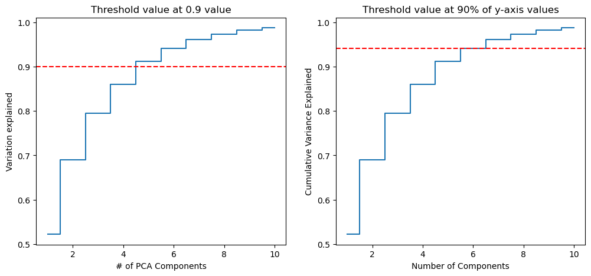

```
Threshold value to consider :  0.940988718801564
```

```python
# plt.bar(list(range(1, len(pca.explained_variance_ratio_) + 1)),pca.explained_variance_ratio_,alpha=0.5, align='center')

plt.figure(figsize=(12, 5))
plt.subplot(1, 2, 1)
plt.step(list(range(1, len(pca.explained_variance_ratio_) + 1)),np.cumsum(pca.explained_variance_ratio_), where='mid')
plt.ylabel('Variation explained')
plt.xlabel('# of PCA Components')
plt.title('Threshold value at 0.9 value')
# Draw a horizontal line at 90% cumulative variance explained
plt.axhline(y=0.9, color='red', linestyle='--')
#Correct threshold has to be calculated based on the variation explained. Hence we will replot the threshold with correct value.
plt.subplot(1, 2, 2)
plt.step(range(1, len(cumulative_variance_ratio) + 1), cumulative_variance_ratio, where='mid')
plt.xlabel('Number of Components')
plt.ylabel('Cumulative Variance Explained')
plt.title('Threshold value at 90% of y-axis values')

cumulative_variance_ratio = np.cumsum(pca.explained_variance_ratio_)
y_threshold = cumulative_variance_ratio.min() + 0.9 * (cumulative_variance_ratio.max() - cumulative_variance_ratio.min())
# Draw a horizontal line at 90% of y axis values
plt.axhline(y=y_threshold, color='r', linestyle='--')

# Show the plot
plt.show()
print('Threshold value to consider : ', y_threshold)
```

### Q.3.F. Apply PCA on the data. This time Select Minimum Components with 90% or above variance explained

```python
# Find the minimum number of components required to explain 90% variance
min_components = np.argmax(np.cumsum(pca.explained_variance_ratio_) >=y_threshold) + 1

print("Minimum PCA components to be considered : " , min_components)
# Create a new PCA object with the minimum number of components
pca_min = PCA(n_components=min_components)

# Fit the PCA object on the scaled data
pca_min.fit(X_scaled)

# Transform the data using the fitted PCA object
X_pca_min = pca_min.transform(X_scaled)

# Convert the transformed data back to a DataFrame
X_pca_min = pd.DataFrame(X_pca_min, columns=[f"PC{i+1}" for i in range(min_components)])
X_pca_min.head()
```

```
Minimum PCA components to be considered :  6
```

|  | PC1 | PC2 | PC3 | PC4 | PC5 | PC6 |
| --- | --- | --- | --- | --- | --- | --- |
| 0 | 0.332184 | -0.218516 | 1.001224 | 0.177483 | 0.079406 | -0.754133 |
| 1 | -1.593949 | -0.420472 | -0.369193 | 0.233851 | 0.694144 | -0.519075 |
| 2 | 3.767402 | 0.194523 | 0.088453 | 1.203255 | 0.731257 | 0.705522 |
| 3 | -1.741189 | -2.829293 | 0.109070 | 0.377862 | -0.363197 | -0.488381 |
| 4 | 0.555825 | 4.756395 | 11.703989 | 0.143922 | 3.258808 | -0.213026 |

```python
# eigen values
print('eigen values:')
print(pca_min.explained_variance_)
# eigen Vectors
print('eigen vectors:')
print(pca_min.components_)
```

```
eigen values:
[9.40857922 3.01607467 1.90353183 1.18000765 0.91741511 0.53910034]
eigen vectors:
[[ 2.75249495e-01  2.93436413e-01  3.04547698e-01  2.67573675e-01
   8.05079747e-02  9.72203204e-02  3.16867212e-01 -3.14037574e-01
   3.13947136e-01  2.82799338e-01  3.09306994e-01  3.14144407e-01
   2.72009995e-01 -2.08336190e-02  4.14105187e-02  5.83399914e-02
   3.01278807e-02  7.40588607e-02]
 [-1.27055575e-01  1.26330928e-01 -7.27506890e-02 -1.89690531e-01
  -1.22182265e-01  1.06897423e-02  4.79997564e-02  1.28570986e-02
   6.01324431e-02  1.16160027e-01  6.16806485e-02  5.32303740e-02
   2.09263671e-01  4.88463802e-01 -5.50779090e-02 -1.24163026e-01
  -5.40948728e-01 -5.40277145e-01]
 [-1.19853746e-01 -2.52398821e-02 -5.60148154e-02  2.75082061e-01
   6.42038232e-01  5.91766796e-01 -9.76428545e-02  5.74644586e-02
  -1.09590705e-01 -1.69747112e-02  5.64756107e-02 -1.08703426e-01
  -3.13400688e-02  2.86289667e-01 -1.15583026e-01 -7.55694009e-02
   8.69213364e-03  3.94843518e-02]
 [ 7.84038098e-02  1.87516003e-01 -7.07747694e-02 -4.23325863e-02
   3.28009096e-02  3.12065929e-02 -9.60582474e-02  8.27336535e-02
  -9.22062973e-02  1.87930150e-01 -1.20378699e-01 -9.11960297e-02
   2.00072843e-01 -6.56568163e-02  6.05005012e-01 -6.65849629e-01
   1.05570734e-01  4.76262274e-02]
 [ 6.94857915e-02 -8.49752988e-02  4.08360619e-02 -4.60900772e-02
  -4.07838041e-02  2.13661914e-01 -1.50654046e-02  7.67824915e-02
   1.04999521e-03 -6.04790437e-02 -4.59460202e-04 -1.93991254e-02
  -6.16233053e-02  1.45630913e-01  7.28928992e-01  5.99425516e-01
  -1.00691588e-01 -2.98902121e-02]
 [ 1.44730971e-01 -3.00273109e-01 -1.38512211e-01  2.48856548e-01
   2.37993647e-01 -4.21399849e-01  1.16506257e-01 -1.42409751e-01
   9.58072037e-02 -4.61726647e-01  2.35866438e-01  1.56401222e-01
  -1.34662989e-01  2.41458292e-01  2.03590849e-01 -1.90574513e-01
   1.56501065e-01 -2.41948784e-01]]
```

### Q.3.G. Train SVM model on components selected from above step

```python
#Lets split data handled using PCA into train and test set to perform SVM. This will ensure data consistency.
X_train_pca, X_test_pca, y_train_pca, y_test_pca = train_test_split(X_pca_min,y, test_size = 0.2, random_state = 10)
print(X_train_pca.shape)
print(X_test_pca.shape)
print(y_train_pca.shape)
print(y_test_pca.shape)
print(X_pca_min.shape)
print(y.shape)
```

```
(676, 6)
(170, 6)
(676,)
(170,)
(846, 6)
(846,)
```

```python
# Train the SVM classifier using the PCA-reduced features on training data
svm_classifier_pca = SVC()
svm_classifier_pca.fit(X_train_pca, y_train_pca)

# Predict the class labels for the training data
y_pred_train_pca = svm_classifier_pca.predict(X_train_pca)
y_pred_test_pca = svm_classifier_pca.predict(X_test_pca)
```

### Q.3.H. Print Classification metrics for train data of above model and share insights

```python
# Calculate and print the classification metrics
accuracy_pca,precision_pca, recall_pca, f1_pca,accuracy_pca_test,precision_pca_test, recall_pca_test, f1_pca_test, results_df = PrintOutput(results_df,'SVM post PCA',X_train_pca, X_test_pca,y_train_pca, y_test_pca,y_pred_train_pca, y_pred_test_pca)
```

```
*************** SVM post PCA ***************
Accuracy on training set :  0.92
Accuracy on test set :  0.85
Recall on training set:  0.92
Recall on test set:  0.85
Precision on training set:  0.92
Precision on test set:  0.86
F1 on train set:  0.92
F1 on test set:  0.85
Classification Report on test data:
              precision    recall  f1-score   support

         bus       0.92      0.77      0.84        44
         car       0.87      0.89      0.88        89
         van       0.76      0.86      0.81        37

    accuracy                           0.85       170
   macro avg       0.85      0.84      0.84       170
weighted avg       0.86      0.85      0.85       170
```

## Q.4. Performance Improvement

### Q.4.A. Train another SVM on the components out of PCA. Tune the parameters to improve performance

```python
#Lets tune the paramegers using GridSearchCV

#Define the parameter grid
param_grid = {
    'C': [ 1, 10, 100],
    'gamma': [0.1,0.0001],
    'kernel': ['linear', 'rbf']
}
# Create a new SVM classifier
svm_classifier_tuned = SVC()

# Perform grid search cross-validation
grid_search = GridSearchCV(svm_classifier_tuned, param_grid, cv=5)
grid_search.fit(X_train_pca, y_train_pca)

# Get the best model
best_model = grid_search.best_estimator_

# Train the best model on the entire training data(pca)
best_model.fit(X_train_pca, y_train_pca)

# Predict the class labels for the training data
y_pred_train_tuned = best_model.predict(X_train_pca)
# Predict the class labels for the testing data
y_pred_test_tuned = best_model.predict(X_test_pca)
```

### Q.4.B. Share best Parameters observed from above step.

```python
print("Best parameters after GridsearchCV tuning:")
print(grid_search.best_params_)
```

```
Best parameters after GridsearchCV tuning:
{'C': 10, 'gamma': 0.1, 'kernel': 'rbf'}
```